# Getting started

## Betweenness / MovementFlow

Finally, in addition to computing habitat functionality or amount of connected habitat, the ConScape library also computes the number of paths going through each pixel weighted by the likelihood of the path, which is a node’s ‘betweenness’ in network sciences.

ConScape also computes the betweenness weighted by the qualities of the source and target node of a path (i.e. quality weighted) and weighted by the qualities of source and target and their proximity (i.e. proximity weighted). This last version is closely related to what Bodin2010ranking called the ‘generalized betweenness centrality’ using the least-cost paths.

The quality weighting `QualityWeighted()` highlights the pixels that are in between high quality pixels:

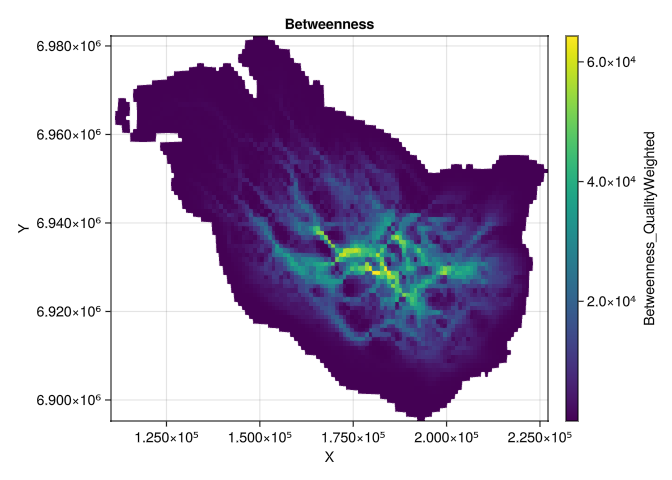

We can use this function to illustrate the effect of the randomness parameter $\theta$. By setting the quality of two pixels to one while all others are zero we can visualize the distribution over paths between these two pixels, for instance, two pixels:

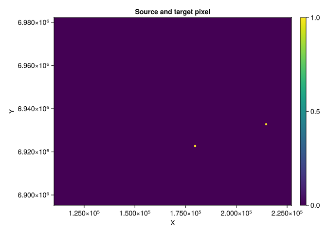

We can now over a range of $\theta$ values show the pixels that are most ‘in-between’ the two focal pixels:

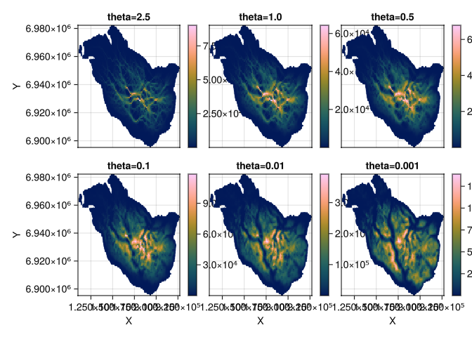

We see that as $\theta$ becomes larger the path distribution becomes narrowly focused on a single path, i.e. the least-cost path, whereas as $\theta$ becomes smaller the path distribution becomes more diffuse, i.e. a random walk.

Finally, the weighting `QualityAndProximityWeighted()` computes the betweenness where paths are weighted by the quality of the source and target, but also by their proximity ($k_{st}$). As this is an important betweenness, we define `MovementFlow` as a shorthand for `Betweenness{QualityAndProximityWeighted}`.

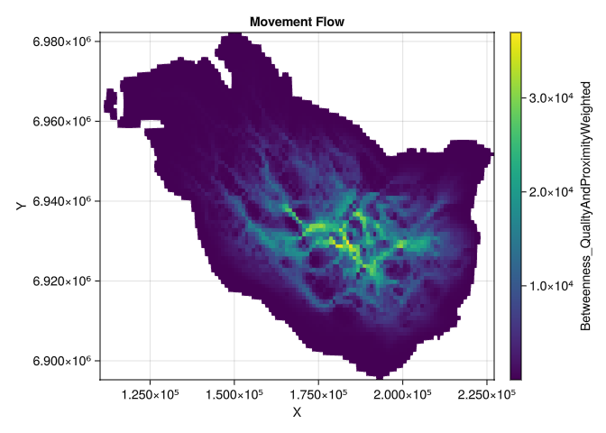

Quality and proximity weighted betweenness, which we refer to as the ‘movement flow’.

`MovementFlow` highlights the pixels that are most in-between high-quality pixels that are functionally connected together. This metric is expected to capture best the actual movement flows on the landscape (bodin2010ranking).

# Step 4: Export

Finally, we can write our outputs to disk using Rasters.jl:

```
"functional_habitat.tif"
```

## Summary

We showed a basic workflow to demonstrate the main functionalities in the ConScape library. Step 1 is data import and the representation of the landscape as a `RasterStack`. In step 2 we define a `MovementMode`, and step 3 we compute measures of habitat functionality and betweenness, illustrating the effect of the randomness parameter $\theta$.

Moorter, Bram van, Ilkka Kivimäki, Manuela Panzacchi, and Marco Saerens. 2021. “Defining and Quantifying Effective Connectivity of Landscapes for Species’ Movements.” *Ecography* 44 (6): 870–84.

Saura, Santiago, Christine Estreguil, Coralie Mouton, and Mónica Rodrı́guez-Freire. 2011. “Network Analysis to Assess Landscape Connectivity Trends: Application to European Forests (1990–2000).” *Ecological Indicators* 11 (2): 407–16.

Saura, Santiago, and Lucı́a Pascual-Hortal. 2007. “A New Habitat Availability Index to Integrate Connectivity in Landscape Conservation Planning: Comparison with Existing Indices and Application to a Case Study.” *Landscape and Urban Planning* 83 (2): 91–103.